# nanoSPLITS C10/SVEC Single Cell Experiment - R Markdown File (Figure 3 and associated supplementary figures)

James M. Fulcher

Last updated: 11/21/2023

# Introduction

This markdown file details the data structure and code used to generate figures for the nanoSPLITS manuscript. For this experiment, C10 mouse type II alveolar cells and SVEC cells were split for parallel transcriptomics and proteomics. For transcriptomics, both raw counts and TPM normalized values were utilized. For proteomics, summarized protein intensities and riBAQ values were utilized.

# Proteomics

## Data structure

We import “C10SVEC_singlecells_Protein_intensities.tsv” and “rIBAQ.RData” for the LFQ proteomic data. “C10SVEC_singlecells_Protein_intensities.tsv” contains the summarized protein intensity values output from FragPipe (17.1). “rIBAQ.RData” contains iBAQ summarized (under variable “response”) protein values which are converted to riBAQ values within this script. iBAQ measurements were calculated using peptide level quant data from FragPipe outside of this script with the aLFQ R package. Several accessory files are needed for reference within the script (“filter.RData”, “protlist.csv”, and “convert_uniprot.tsv”).

## Data Quality Control

For quality control of proteomics data, samples with less than 1,000 identified proteins were removed from downstream analysis. To accomplish dimensional reduction of proteomics data, values were imputed using DreamAI. For Figure 3d, only proteins with less than 40% missingness in both SVEC and C10 were imputed and retained. For Figure 3e, only proteins in C10 with less than 40% missingness were imputed and retained.

# Transcriptomics

## Data structure

We import “C10SVEC_singlecells_Counts.txt” and “C10SVEC_singlecells_TPM.txt” for raw counts and TPM normalized expression values of the transcriptomic data, respectively. This experiment relies more heavily on raw counts, which are utilized in SCNorm in order to perform between-sample normalization. Normalized expression counts were read into the markdown file with “C10SVEC_singlecells_norm_counts.csv”.

## Data Quality Control

For quality control of transcriptomics data, separate criteria are used depending on cell type. For C10, cells with more than 3,000 genes supported by a minimum of 5 raw counts are retained. For SVEC, cells with more than 2,000 genes supported by a minimum of 5 raw counts are retained.

# Relevant Code Chunks

## Data import

```r
path <- "./"
knitr::opts_chunk$set(echo = TRUE)
knitr::opts_knit$set(rootdir = path)
setwd(path)
library(tidyverse); library(proDA);library(aLFQ);library(knitr); library(ggrepel);
library(vegan);library(corrplot); library(org.Mm.eg.db); library(AnnotationDbi);
library(corrr); library(reshape2);library(PCAtools);
library(fs);library(SC3); library(SingleCellExperiment);library(scater);
library(Seurat); library(SeuratData); library(cowplot);library(data.table);
library(viridis)

singcell <- read_tsv("C10SVEC_singlecells_Protein_intensities.tsv", show_col_types = FALSE)
RNAx <- read.delim("C10SVEC_singlecells_Counts.txt", check.names = FALSE )
RNA_norm3 <- read.csv("C10SVEC_singlecells_norm_counts.csv", check.names = FALSE)
RNAx_TPM <- read.delim("C10SVEC_singlecells_TPM.txt", check.names = FALSE)
names(RNAx_TPM)[names(RNAx_TPM) == ''] <- 'Gene'
RNAx_counts <- read.delim("C10SVEC_singlecells_Counts.txt", check.names = FALSE)
names(RNAx_counts)[names(RNAx_counts) == ''] <- 'Gene'

load("rIBAQ.RData")
load("filter.RData")

protlist <- read.csv("protlist.csv")
convert <- read_tsv("convert_uniprot.tsv")
s.genes <- read.csv("sgenes.csv", header = FALSE,
                    check.names = FALSE)$V1
g2m.genes <- read.csv("g2mgenes.csv", header = FALSE)$V1
```

```r
singcell2 <- singcell %>%
  filter(!grepl("contam_sp", PROTID))
singcell2[singcell2 == 0] <- NA


singcell2[,2:71] <- log2(singcell2[,2:71])
singcell_long1 <- singcell2 %>%
  pivot_longer(!PROTID, names_to = "SampleID", values_to = "Intensity") %>%
  filter(!is.na(Intensity))


names(RNAx)[names(RNAx) == ''] <- 'Gene'
RNAx2 <- RNAx %>%
  pivot_longer(!Gene, names_to = "SampleID", values_to = "Counts") %>%
  filter(Counts > 4)


RNAx3 <- RNAx2 %>%
    mutate(Type = case_when(grepl("05J", SampleID) ~ "C10",
                            grepl("07J", SampleID) ~ "SVEC")) %>%
  group_by(SampleID) %>%
  add_count(name = "n") %>%
  mutate(Filter1 = case_when(Type == "C10" & n >= 3000 ~ "Keep",
                             Type == "SVEC" & n >= 2000 ~ "Keep",
                             TRUE ~ "Remove")) %>%
  filter(Filter1 == "Keep") %>%
  ungroup() %>%
  dplyr::select(-n, -Type, -Filter1)
```

## Post-normalization of scRNAseq data with SCNorm

```r
names(RNA_norm3)[names(RNA_norm3) == ''] <- 'Gene'

 RNA_norm3 <- RNA_norm3 %>%
   remove_rownames %>% column_to_rownames(var= "Gene" )


RNAx4 <- RNA_norm3 %>%
  tibble::rownames_to_column(var = "Gene") %>%
  pivot_longer(!Gene, names_to = "SampleID", values_to = "Counts") %>%
  filter(Counts >= 5)
```

## Convert UNIPROT accessions to gene symbols, and perform inference

```r
UniAc <- unique(singcell_long1$PROTID)

geneSymbols <- select(org.Mm.eg.db, keys=UniAc, columns= c("SYMBOL","UNIPROT"),
                      keytype="UNIPROT", multiVals="first")

geneSymbols <- geneSymbols %>%
  mutate(Gene = SYMBOL) %>%
  dplyr::select(Gene,UNIPROT)

convert <- read_tsv("convert_uniprot.tsv")

geneSymbols <- full_join(geneSymbols, convert, by = c("Gene","UNIPROT")) %>%
  filter(!is.na(Gene))

singcell_long2 <- singcell_long1 %>%
  filter(!is.na(Intensity)) %>%
  mutate(UNIPROT = PROTID)

singcell_long2 <- full_join(singcell_long2,geneSymbols, by = "UNIPROT") %>%
  mutate(Gene = case_when(is.na(Gene) ~ UNIPROT,
                          TRUE ~ Gene)) %>%
  group_by(SampleID, Gene) %>%
  slice_max(order_by = Intensity, n = 1 , with_ties = FALSE)  %>%
  ungroup()


###### Inference

combined3 <- full_join(singcell_long2, RNAx4, by = c("SampleID", "Gene"))


inference1 <- combined3 %>%
  filter(!is.na(Intensity)) %>%
  group_by(SampleID, Intensity) %>%
  add_count(name = "n") %>%
  filter(n > 1) %>%
  ungroup() %>%
  distinct(Gene,UNIPROT)



inference2 <- combined3 %>%
  filter(!is.na(Intensity) & !is.na(Counts)) %>%
  group_by(SampleID, Intensity) %>%
  add_count(name = "n") %>%
  filter(n > 1) %>%
  distinct(n, Gene, Counts, UNIPROT) %>%
  group_by(Gene) %>%
  add_count(name  = "n2") %>%
  group_by(Gene) %>%
  slice_max(order_by = n2, n = 1) %>%
  mutate(med = median(Counts)) %>%
  group_by(UNIPROT) %>%
  slice_max(order_by = med, n = 1, with_ties = FALSE) %>%
  ungroup() %>%
  distinct(UNIPROT, Gene)

inference3 <- inference1 %>%
  filter(!Gene %in% inference2$Gene)

singcell_long3 <- singcell_long2 %>%
  filter(!Gene %in% inference3$Gene) %>%
  filter(!is.na(SampleID))
```

```r
##Filter samples with high keratin contam
removeID <- singcell_long3 %>%
    mutate(keratin = case_when(grepl("Krt", Gene) ~ "Yes",
                             TRUE ~ "No")) %>%
    filter(keratin == "Yes") %>%
  group_by(SampleID) %>%
  summarize(med = median(Intensity)) %>%
  filter(med > 20) %>%
  distinct(SampleID)
```

```r
singcell3 <- singcell_long3 %>%
  mutate(Type = case_when(grepl("05J", SampleID) ~ "C10",
                          grepl("07J", SampleID) ~ "SVEC")) %>%
  filter(!grepl("Krt", Gene)) %>%
  filter(!SampleID %in% removeID$SampleID) %>%
  group_by(SampleID) %>%
  add_count(name = "n") %>%
  filter(n >= 1000) %>%
  dplyr::select(-n) %>%
  pivot_wider(id_cols = "Gene", names_from = "SampleID",
              values_from = "Intensity")



C10cell <- singcell3 %>%
  dplyr::select(starts_with("Gene")| starts_with("05J"))

C10cell <- C10cell %>% remove_rownames %>% column_to_rownames(var="Gene")
C10cell <- as.data.frame(median_normalization(as.matrix(C10cell)))
C10cell_long <- C10cell %>%
  rownames_to_column(., "Gene") %>%
  pivot_longer(!Gene, names_to = "SampleID", values_to = "Intensity")

SVECcell <- singcell3 %>%
  dplyr::select(starts_with("Gene")| starts_with("07J"))

SVECcell <- SVECcell %>% remove_rownames %>% column_to_rownames(var="Gene")

SVECcell <- as.data.frame(median_normalization(as.matrix(SVECcell)))
SVECcell_long <- SVECcell %>%
  rownames_to_column(., "Gene") %>%
  pivot_longer(!Gene, names_to = "SampleID", values_to = "Intensity")

singcell_long <- rbind(C10cell_long,SVECcell_long) %>%
  filter(!is.na(Intensity))
```

## Intermediate step to combine scRNAseq and scProteomic data

```r
RNAx5 <- RNAx4 %>%
  mutate(SampleID = paste0(SampleID, "_RNA")) %>%
  mutate(Intensity = log2(Counts)) %>%
  filter(!is.na(Counts)) %>%
  ungroup()



combined4 <- full_join(singcell_long, RNAx5) %>%
  filter(!is.na(SampleID)) %>%
  dplyr::select(-Counts)



samp_filter2 <- unique(RNAx4$SampleID)
samp_filter <- unique(singcell_long$SampleID)
```

## Figure 3b code

```r
RNAx2 <- RNAx_TPM %>%
  pivot_longer(!Gene, names_to = "SampleID", values_to = "TPM")

RNAx3 <- RNAx_counts %>%
  pivot_longer(!Gene, names_to = "SampleID", values_to = "Counts")

RNAx4 <- inner_join(RNAx2, RNAx3)


correlation_gene <- inner_join(singcell_long, RNAx4) %>%
  filter(!is.na(TPM)) %>%
  filter(TPM >= 0.1) %>%
  mutate(TPM = log2(TPM))

datatest <- correlation_gene %>%
  mutate(Type = case_when(grepl("C10_", SampleID) ~ "C10",
                          grepl("SVEC", SampleID) ~ "SVEC")) %>%
  filter(Type  == "C10" | Type == "SVEC") %>%
  group_by(Gene, Type) %>%
  add_count(name = "Obs") %>%
  filter(Obs >= 4) %>%
  ungroup()



datatest <- as_tibble(datatest)


data_nest <- group_by(datatest,Type, Gene) %>% nest()

cor_fun <- function(df) cor.test(df$Intensity, df$TPM, method = "pearson") %>%
  broom::tidy()

data_nest <- mutate(data_nest, model = map(data, cor_fun))
corr_pr <- dplyr::select(data_nest, -data) %>% unnest(cols = c(model))
corr_pr <- corr_pr %>%
  ungroup() %>%
  mutate(FDR = p.adjust(`p.value`, method = "BH")) %>%
  mutate(Type2 = "mRNA-Protein")

set.seed(524)
datatest <- correlation_gene %>%
  mutate(Type = case_when(grepl("C10_", SampleID) ~ "C10",
                          grepl("SVEC", SampleID) ~ "SVEC")) %>%
  filter(Type  == "C10" | Type == "SVEC") %>%
  group_by(Gene, Type) %>%
  add_count(name = "Obs") %>%
  filter(Obs >= 4) %>%
  transform(TPM = sample(TPM)) %>%
  transform(Intensity = sample(Intensity)) %>%
  ungroup()

datatest <- as_tibble(datatest)

data_nest <- group_by(datatest,Type, Gene) %>% nest()

cor_fun <- function(df) cor.test(df$Intensity, df$TPM, method = "pearson") %>%
  broom::tidy()

data_nest <- mutate(data_nest, model = map(data, cor_fun))
corr_pr2 <- dplyr::select(data_nest, -data) %>% unnest(cols = c(model))
corr_pr2 <- corr_pr2 %>%
  ungroup() %>%
  mutate(FDR = p.adjust(`p.value`, method = "BH")) %>%
  mutate(Type2 = "Randomized")

combined_pearson <- full_join(corr_pr, corr_pr2)

main1 <- combined_pearson %>%
  ggplot()+
  aes(x = estimate, fill = Type2)+
  geom_histogram(alpha = 0.6,
                 position = "identity",
                 bins = 100)+
  xlab("")+
  ylab("Genes (n)")+
  theme_minimal(base_size = 24)+
  theme(panel.grid.minor = element_blank(),
        panel.grid.major = element_blank(),
        panel.border = element_blank(),
        axis.line = element_line())+
  scale_fill_brewer(name = "", palette = 2,type = "qual",
                    direction = -1)+
  theme(legend.position = "bottom",
        legend.direction = "vertical",
        legend.box = "horizontal")+
  geom_vline(xintercept = 0)


 wilcox.test(corr_pr$estimate, corr_pr2$estimate, alternative = "two.sided")
```

## Figure 3c,d code

```r
C10SVEC.rna <- read.csv(file = "C10SVEC_singlecells_norm_counts.csv", sep = ",",
                          header = TRUE, row.names = 1, check.names = FALSE) %>%
  as.sparse()

names <- C10SVEC.rna@Dimnames[[2]]


C10SVEC.prot <- read.csv(file = "C10SVEC_singlecells_protein_impute.csv", sep = ",",
                         header = TRUE, row.names = 1, check.names = FALSE) %>%
  as.sparse()


names2 <- C10SVEC.prot@Dimnames[[2]]

C10SVEC_sub.rna <- read.csv(file = "C10SVEC_singlecells_norm_counts.csv", sep = ",",
                            header = TRUE, row.names = 1, check.names = FALSE) %>%
  dplyr::select(one_of(names2)) %>%
  as.sparse()

check <- colnames(C10SVEC_sub.rna)



C10SVEC_sub.prot <- read.csv(file = "C10SVEC_singlecells_protein_impute.csv", sep = ",",
                             header = TRUE, row.names = 1, check.names = FALSE) %>%
  dplyr::select(one_of(names))


C10SVEC_sub.prot <- C10SVEC_sub.prot[ , check] %>%
  as.sparse()



C10SVEC <- CreateSeuratObject(counts = C10SVEC_sub.rna)

prot_assay <- CreateAssayObject(counts = C10SVEC_sub.prot)

C10SVEC[["Prot"]] <- prot_assay

DefaultAssay(C10SVEC) <- 'RNA'

C10SVEC <- NormalizeData(C10SVEC)

C10SVEC <- FindVariableFeatures(C10SVEC,
                                selection.method = "disp")
C10SVEC <- ScaleData(C10SVEC)
C10SVEC <- RunPCA(C10SVEC, verbose = FALSE,
                  npcs = 48)
C10SVEC <- FindNeighbors(C10SVEC, dims = 1:4)
C10SVEC <- FindClusters(C10SVEC, resolution = 1, verbose = FALSE)
C10SVEC <- RunUMAP(C10SVEC, dims = 1:4)


DefaultAssay(C10SVEC) <- 'Prot'

VariableFeatures(C10SVEC) <- rownames(C10SVEC[["Prot"]])
C10SVEC <-  ScaleData(C10SVEC) %>% RunPCA(reduction.name = 'apca',
                                          npcs = 48)

C10SVEC <- RenameIdents(C10SVEC, "0" = '  C10', "1" = 'SVEC  ')
levels(C10SVEC)
C10SVEC$celltype <- Idents(C10SVEC)
C10SVEC <- FindMultiModalNeighbors(
  C10SVEC, reduction.list = list("pca", "apca"),
  dims.list = list(1:4, 1:3),
  knn.range = 48, smooth = FALSE,
  return.intermediate = TRUE,
  modality.weight.name = c("RNA.weight", "Prot.weight"))

C10SVEC <- RunUMAP(C10SVEC, nn.name = "weighted.nn", reduction.name = "wnn.umap", reduction.key = "wnnUMAP_")
C10SVEC <- FindClusters(C10SVEC, graph.name = "wsnn", algorithm = 1, resolution = 1, verbose = FALSE)

C10SVEC <- RenameIdents(C10SVEC, "0" = 'C10    ',"1" = "   SVEC")
levels(C10SVEC)
C10SVEC$celltype <- Idents(C10SVEC)


p1 <- DimPlot(C10SVEC, group.by = "celltype",
              reduction = 'wnn.umap', label = FALSE, repel = TRUE, label.size = 5,
              pt.size = 3.5,
              cols = c("#00D65C","#82B7FF")) + NoLegend()+
  scale_x_continuous(limits = c(-7, 7))+
  scale_y_continuous(limits = c(-8,9))

p2 <- FeaturePlot(C10SVEC,label = FALSE, features = c("rna_H2-K1"),
                  reduction = 'wnn.umap', max.cutoff = 100,
                  cols = c("lightgrey", "purple"),
                  ncol = 1,
                  repel = TRUE,
                  order = TRUE,
                  slot = "scale.data",
                  pt.size = 3.5)+
  scale_x_continuous(limits = c(-7, 7))+
  scale_y_continuous(limits = c(-8,9))

p3 <- FeaturePlot(C10SVEC,label = FALSE, features = c("prot_H2-K1"),
                  reduction = 'wnn.umap', max.cutoff = 100,
                  ncol = 1,
                  cols = c("lightgrey", "red"),
                  repel = TRUE,
                  order = TRUE,
                  slot = "scale.data",
                  pt.size = 3.5)+
  scale_x_continuous(limits = c(-7, 7))+
  scale_y_continuous(limits = c(-8,9))
```

## Figure 3a code

```r
test2 <- test %>%
  group_by(run_id) %>%
  mutate(Total = sum(response)) %>%
  ungroup() %>%
  mutate(riBAQ = response/Total) %>%
  group_by(protein_id) %>%
  summarize(median = median(riBAQ))

test2$Rank <- rank(-test2$median)

test3 <- test %>%
  group_by(run_id) %>%
  mutate(Total = sum(response)) %>%
  ungroup() %>%
  mutate(riBAQ = response/Total) %>%
  mutate(SampleID = run_id) %>%
  inner_join(., protlist) %>%
  dplyr::select(SampleID, PROTID, riBAQ)



test3 <- test3 %>%
  group_by(SampleID) %>%
  add_count(name = "n") %>%
  filter(n >= 1000) %>%
  dplyr::select(-n)



RNAx2 <- RNAx_TPM %>%
  pivot_longer(!Gene, names_to = "SampleID", values_to = "TPM")

RNAx3 <- RNAx_counts %>%
  pivot_longer(!Gene, names_to = "SampleID", values_to = "Counts")

RNAx4 <- inner_join(RNAx2, RNAx3)


RNAx5 <- RNAx4 %>%
  filter(Counts >= 5) %>%
  mutate(Type = case_when(grepl("05J", SampleID) ~ "C10",
                          grepl("07J", SampleID) ~ "SVEC")) %>%
  group_by(SampleID) %>%
  add_count(name = "n") %>%
  mutate(Filter1 = case_when(Type == "C10" & n >= 3000 ~ "Keep",
                             Type == "SVEC" & n >= 2000 ~ "Keep",
                             TRUE ~ "Remove")) %>%
  filter(Filter1 == "Keep") %>%
  ungroup() %>%
  dplyr::select(-Counts, -n, -Type, -Filter1)


UniAc <- unique(test3$PROTID)

geneSymbols <- select(org.Mm.eg.db, keys=UniAc, columns= c("SYMBOL","UNIPROT"),
                      keytype="UNIPROT", multiVals="first")


geneSymbols <- geneSymbols %>%
  mutate(Gene = SYMBOL) %>%
  dplyr::select(Gene,UNIPROT)



geneSymbols <- full_join(geneSymbols, convert, by = c("Gene","UNIPROT")) %>%
  filter(!is.na(Gene))

test4 <- test3 %>%
  mutate(UNIPROT = PROTID)


x_long2 <- inner_join(test4,geneSymbols, by = "UNIPROT") %>%
  mutate(Gene = case_when(is.na(Gene) ~ UNIPROT,
                          TRUE ~ Gene)) %>%
  group_by(SampleID, Gene) %>%
  mutate(logriBAQ = log2(riBAQ)) %>%
  slice_max(order_by = logriBAQ, n = 1 , with_ties = FALSE)  %>%
  ungroup()


###### Inference

combined3 <- full_join(x_long2, RNAx5, by = c("SampleID", "Gene"))


inference1 <- combined3 %>%
  filter(!is.na(logriBAQ)) %>%
  group_by(SampleID, logriBAQ) %>%
  add_count(name = "n") %>%
  filter(n > 1) %>%
  ungroup() %>%
  distinct(Gene,UNIPROT)



inference2 <- combined3 %>%
  filter(!is.na(logriBAQ) & !is.na(TPM)) %>%
  group_by(SampleID, logriBAQ) %>%
  add_count(name = "n") %>%
  filter(n > 1) %>%
  distinct(n, Gene, TPM, UNIPROT) %>%
  group_by(Gene) %>%
  add_count(name  = "n2") %>%
  group_by(Gene) %>%
  slice_max(order_by = n2, n = 1) %>%
  mutate(med = median(TPM)) %>%
  group_by(UNIPROT) %>%
  slice_max(order_by = med, n = 1, with_ties = FALSE) %>%
  ungroup() %>%
  distinct(UNIPROT, Gene)

inference3 <- inference1 %>%
  filter(!Gene %in% inference2$Gene)

x_long3 <- x_long2 %>%
  filter(!Gene %in% inference3$Gene)


RNAx6 <- RNAx5 %>%
  mutate(SampleID = paste0(SampleID, "_RNA")) %>%
  mutate(logriBAQ = log2(TPM)) %>%
  filter(!is.na(TPM)) %>%
  ungroup()

combined4 <- full_join(x_long3, RNAx6) %>%
  filter(!is.na(SampleID)) %>%
  filter(grepl(paste(datafilter_ibaq, collapse = "|"), SampleID)) %>%
  filter(!SampleID %in%  c("05J_C10_B12_RNA","07J_SVEC_A11_RNA",
                           "05J_C10_D10_RNA","05J_C10_D12_RNA",
                           "07J_SVEC_B12_RNA", "07J_SVEC_B12")) %>%
  dplyr::select(-TPM, -UNIPROT, -PROTID, -riBAQ)


corx <- combined4 %>%
  spread(SampleID, logriBAQ) %>%
  ungroup()

corx2 <- corx %>% remove_rownames %>% column_to_rownames(var="Gene")

corTest <- cor(corx2, use = "pairwise.complete.obs")
```

# Main Figures

## Figure 3a. Pearson correlation heatmap of SVEC and C10 cells (and associated code)

```r
corrplot(corTest, method = 'shade', order = 'hclust',
         hclust.method = 'centroid',
         is.corr = TRUE, tl.srt = 45,
         #col.lim = c(min(corTest),max(corTest)),
         diag = FALSE,
         #type = "lower",
         tl.col = "black",
         cl.pos = "b",
         cl.cex = 2,
         col.lim = c(0, 1),
         tl.pos = "n"
) %>%
  corrRect(c(0, 27, 50,
             73,99), col = 'white',
           lwd = 10)+
  theme(text=element_text(family="Helvetica"))
```

[figure not shown]

## Figure 3d. WNN UMAP with H2-K1 protein/gene expression for C10 and SVEC cells

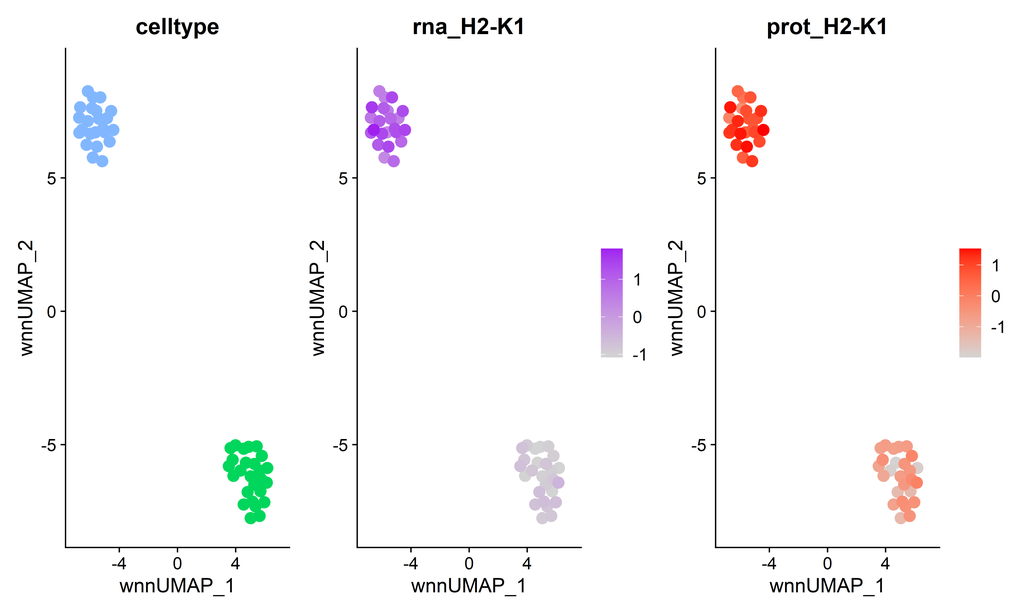

**Supplementary Figure 5a: Distributions of Pearson Correlation coefficients**

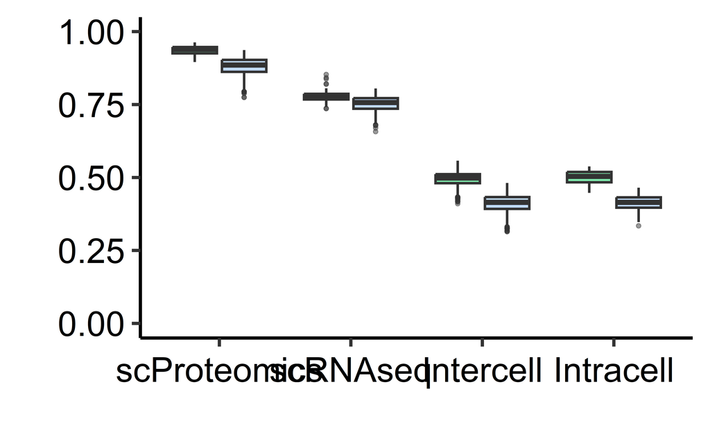

```r
corTest[lower.tri(corTest)] <- NA

corTest2 <- corTest %>%
  melt()

corTest2 %>%
  filter(value != 1) %>%
  filter(!is.na(value)) %>%
  mutate(Var1 = paste(Var1, "_", sep =  "")) %>%
  mutate(Var2 = paste(Var2, "_", sep = "")) %>%
  mutate(Type1 = case_when(grepl("05J", Var1) ~ "C10",
                           grepl("07J", Var1) ~ "SVEC")) %>%
  mutate(Type2 = case_when(grepl("05J", Var2) ~ "C10",
                           grepl("07J", Var2) ~ "SVEC")) %>%
  mutate(Var1 = case_when(Type1 == "C10" ~ paste("__", Var1, sep =  ""),
                          TRUE ~ Var1)) %>%
  mutate(Var2 = case_when(Type2 == "C10" ~ paste("__", Var2, sep =  ""),
                          TRUE ~ Var2)) %>%
  mutate(Comparison = case_when(Type1 == Type2 & grepl("_RNA", Var1) & grepl("_RNA", Var2) ~ "scRNAseq",
                                Type1 == Type2 & !grepl("_RNA", Var1) & !grepl("_RNA", Var2)~ "scProteomics",
                                Type1 == Type2 & !grepl("_RNA", Var1) & grepl("_RNA", Var2) ~ "scProteomics vs scRNAseq",
                                Type1 == Type2 & grepl("_RNA", Var1) & !grepl("_RNA", Var2) ~ "scProteomics vs scRNAseq",
                                TRUE ~ "discard")) %>%
    mutate(Comparison = case_when(Type1 == Type2 & Comparison == "scProteomics vs scRNAseq" & substring(Var1, 10,12) == substring(Var2, 10,12) ~ "Intracell",
                                Type1 == Type2 & Comparison == "scProteomics vs scRNAseq" & substring(Var1, 10,12) != substring(Var2, 10,12) ~ "Intercell",
                                TRUE ~ Comparison)) %>%
  filter(Comparison  != "discard") %>%
  ggplot()+
  aes(x = fct_relevel(Comparison, "scProteomics",
                      "scRNAseq",
                      "scProteomics vs scRNAseq"),
      y = value, fill = Type1)+
  geom_boxplot(alpha = 0.5, show.legend = FALSE, size = 1)+
  theme_bw(base_size = 28) +
  theme(panel.background = element_rect(fill= 'white'),
        axis.text.y=element_text(color = 'black', size = 28),
        axis.text.x=element_text(angle = 0, vjust = 0.5, hjust= 0.5, color='black',size = 28),
        panel.grid.minor = element_blank(),
        panel.grid.major = element_blank(),
        panel.border = element_blank(),
        axis.line = element_line(),
        text=element_text(family="Helvetica")) +
  ylab("") +
  xlab("")+
  scale_x_discrete(labels=function(x){sub("\\s", "\n", x)})+
  scale_fill_manual( values = c("#00D65C", "#82B7FF"))+
  scale_y_continuous(limits = c(0,1))
```

```r
 # ggsave("Pearson_Corr.png", width = 12, height = 6)
```

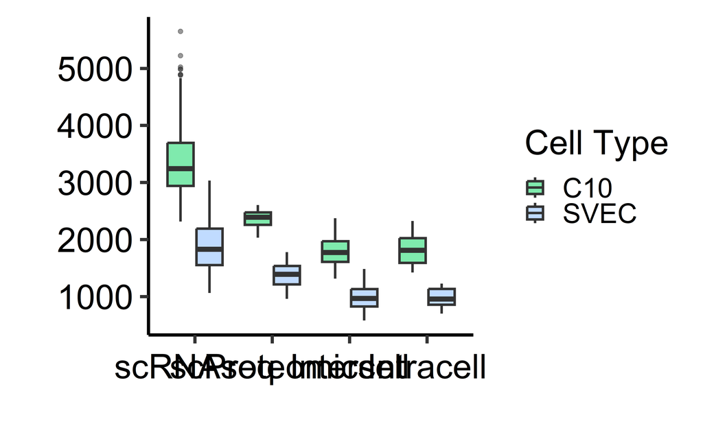

```r
corx <- combined4 %>%
  arrange(SampleID) %>%
  spread(SampleID, logriBAQ) %>%
  ungroup()

corx <- corx %>%
  remove_rownames() %>%
  column_to_rownames("Gene")

combined_cor <- Hmisc::rcorr(as.matrix(corx))

ncor <- as.matrix(combined_cor$n)


ncor[lower.tri(ncor)] <- NA

ncor2 <- ncor %>%
  melt()

ncor2 %>%
    filter(!is.na(value)) %>%
  filter(Var1 != Var2) %>%
mutate(Var1 = paste(Var1, "_", sep =  "")) %>%
  mutate(Var2 = paste(Var2, "_", sep = "")) %>%
  mutate(Type1 = case_when(grepl("05J", Var1) ~ "C10",
                           grepl("07J", Var1) ~ "SVEC")) %>%
  mutate(Type2 = case_when(grepl("05J", Var2) ~ "C10",
                           grepl("07J", Var2) ~ "SVEC")) %>%
  mutate(Var1 = case_when(Type1 == "C10" ~ paste("__", Var1, sep =  ""),
                          TRUE ~ Var1)) %>%
  mutate(Var2 = case_when(Type2 == "C10" ~ paste("__", Var2, sep =  ""),
                          TRUE ~ Var2)) %>%
  mutate(Comparison = case_when(Type1 == Type2 & grepl("_RNA", Var1) & grepl("_RNA", Var2) ~ "scRNAseq",
                                Type1 == Type2 & !grepl("_RNA", Var1) & !grepl("_RNA", Var2)~ "scProteomics",
                                Type1 == Type2 & !grepl("_RNA", Var1) & grepl("_RNA", Var2) ~ "scProteomics vs scRNAseq",
                                Type1 == Type2 & grepl("_RNA", Var1) & !grepl("_RNA", Var2) ~ "scProteomics vs scRNAseq",
                                TRUE ~ "discard")) %>%
    mutate(Comparison = case_when(Type1 == Type2 & Comparison == "scProteomics vs scRNAseq" & substring(Var1, 10,12) == substring(Var2, 10,12) ~ "Intracell",
                                Type1 == Type2 & Comparison == "scProteomics vs scRNAseq" & substring(Var1, 10,12) != substring(Var2, 10,12) ~ "Intercell",
                                TRUE ~ Comparison)) %>%
  filter(Comparison  != "discard") %>%
  ggplot()+
  aes(x = fct_relevel(Comparison,"scRNAseq", "scProteomics",
                      "Proteomics vs RNAseq"),
      y = value, fill = Type1)+
  geom_boxplot(alpha = 0.5, show.legend = TRUE, size = 1)+
  theme_bw(base_size = 28) +
  theme(panel.background = element_rect(fill= 'white'),
        axis.text.y=element_text(color = 'black', size = 28),
        axis.text.x=element_text(angle = 0, vjust = 0.5, hjust= 0.5, color='black',size = 28),
        panel.grid.minor = element_blank(),
        panel.grid.major = element_blank(),
        panel.border = element_blank(),
        axis.line = element_line(),
        text=element_text(family="Helvetica")) +
  ylab("") +
  xlab("")+
  scale_x_discrete(labels=function(x){sub("\\s", "\n", x)})+
  scale_fill_manual(name = "Cell Type", values = c("#00D65C", "#82B7FF"))
```

```r
    #ggsave("overlap.png", width = 12, height = 6)
```

## Supplementary Figure S7a

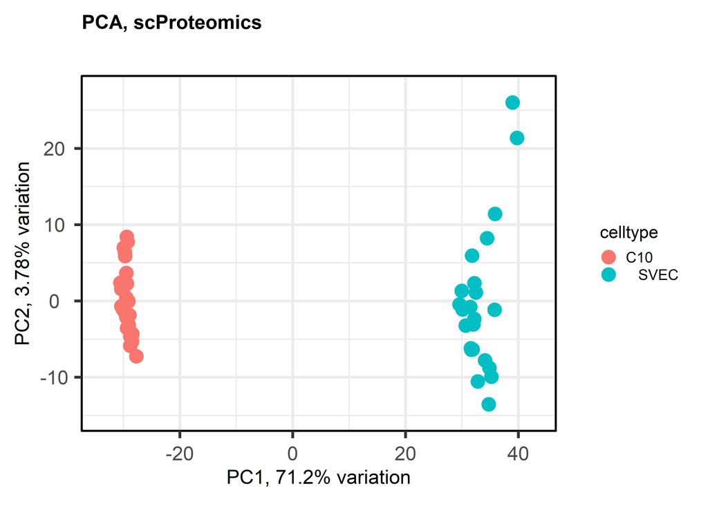

## Supplementary Figure S7b

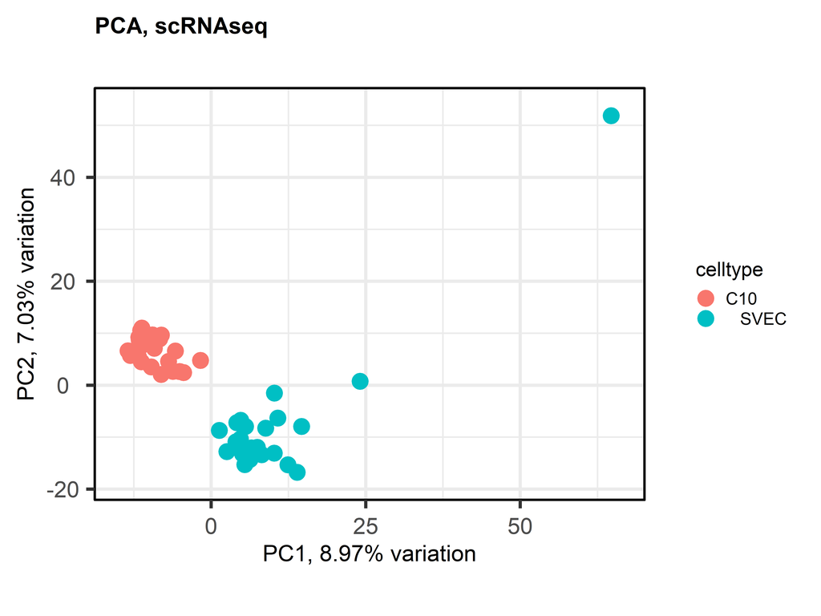

## Figure 3e code

```r
C10SVEC.rna <- read.csv(file = "C10SVEC_singlecells_norm_counts.csv", sep = ",",
                               header = TRUE, row.names = 1, check.names = FALSE) %>%
  dplyr::select( starts_with("05J")) %>%
  as.sparse()

names <- C10SVEC.rna@Dimnames[[2]]


C10SVEC.prot <- read.csv(file = "C10_singlecells_protein_impute.csv", sep = ",",
                         header = TRUE, row.names = 1, check.names = FALSE) %>%
  as.sparse()


names2 <- C10SVEC.prot@Dimnames[[2]]

C10SVEC_sub.rna <- read.csv(file = "C10SVEC_singlecells_norm_counts.csv", sep = ",",
                        header = TRUE, row.names = 1, check.names = FALSE) %>%
  dplyr::select( starts_with("05J")) %>%
             dplyr::select(one_of(names2))

names(C10SVEC_sub.rna) <- gsub(x = names(C10SVEC_sub.rna),
                               pattern = "05J_C10_", replacement = "")
C10SVEC_sub.rna <- as.sparse(C10SVEC_sub.rna)

check <- colnames(C10SVEC_sub.rna)



C10SVEC_sub.prot <- read.csv(file = "C10_singlecells_protein_impute.csv", sep = ",",
                           header = TRUE, row.names = 1, check.names = FALSE) %>%
  dplyr::select( starts_with("05J")) %>%
  dplyr::select(one_of(names))

names(C10SVEC_sub.prot) <- gsub(x = names(C10SVEC_sub.prot),
                               pattern = "05J_C10_", replacement = "")

C10SVEC_sub.prot <- C10SVEC_sub.prot[ , check] %>%
  as.sparse()

# creates a Seurat object based on the scRNA-seq data
C10SVEC <- CreateSeuratObject(counts = C10SVEC_sub.rna)

# We can see that by default, the cbmc object contains an assay storing RNA measurement
Assays(C10SVEC)

# create a new assay to store ADT information
prot_assay <- CreateAssayObject(counts = C10SVEC_sub.prot)

# add this assay to the previously created Seurat object
C10SVEC[["Prot"]] <- prot_assay

# Validate that the object now contains multiple assays
Assays(C10SVEC)

rownames(C10SVEC[["Prot"]])

# List the current default assay
DefaultAssay(C10SVEC)
DefaultAssay(C10SVEC) <- 'RNA'


C10SVEC <- NormalizeData(C10SVEC)
C10SVEC <- FindVariableFeatures(C10SVEC,
                                nfeatures = 3000)
C10SVEC <- ScaleData(C10SVEC)
C10SVEC <- RunPCA(C10SVEC, verbose = FALSE,
                  npcs = 25)
C10SVEC <- FindNeighbors(C10SVEC, dims = 1:2)
C10SVEC <- FindClusters(C10SVEC, resolution = 1,verbose = FALSE)
C10SVEC <- RunUMAP(C10SVEC, dims = 1:2,
                   n.neighbors = 25)


C10SVEC <- CellCycleScoring(C10SVEC, s.features = s.genes, g2m.features = g2m.genes,
                            set.ident = TRUE)

C10SVEC <- RunPCA(C10SVEC, features = c(s.genes, g2m.genes),
                  npcs = 25)


p4 <- DimPlot(C10SVEC, label = FALSE,
        pt.size = 6) +  scale_x_continuous(limits = c(-5, 3))+
  scale_y_continuous(limits = c(-2.5,3))

p5 <- FeaturePlot(C10SVEC,label = FALSE, features = c("Cdk1"),
                  reduction = 'umap', max.cutoff = 100,
                  #cols = c("#ffdb00","#ffa904", "#ee7b06", "#a12424", "#400b0b"),
                  cols = c("lightgrey", "purple"),
                  ncol = 1,
                  repel = TRUE,
                  order = TRUE,
                  slot = "scale.data",
                  pt.size = 6)+
  scale_x_continuous(limits = c(-5, 3))+
  scale_y_continuous(limits = c(-2.5,3))

DefaultAssay(C10SVEC) <- 'Prot'
C10SVEC <- FindVariableFeatures(C10SVEC)
C10SVEC <-  ScaleData(C10SVEC) %>% RunPCA(reduction.name = 'apca',
                                          npcs = 25)


p6 <- FeaturePlot(C10SVEC,label = FALSE, features = c("prot_Cdk1"),
            reduction = 'umap', max.cutoff = 100,
            #cols = c("#ffdb00","#ffa904", "#ee7b06", "#a12424", "#400b0b"),
            cols = c("lightgrey", "red"),
            ncol = 1,
            repel = TRUE,
            order = TRUE,
            slot = "scale.data",
            pt.size = 6)+
  scale_x_continuous(limits = c(-5, 3))+
  scale_y_continuous(limits = c(-2.5,3))
```

## Figure 3e. Cell cycle UMAP with Cdk1 protein/gene expression for C10 cells

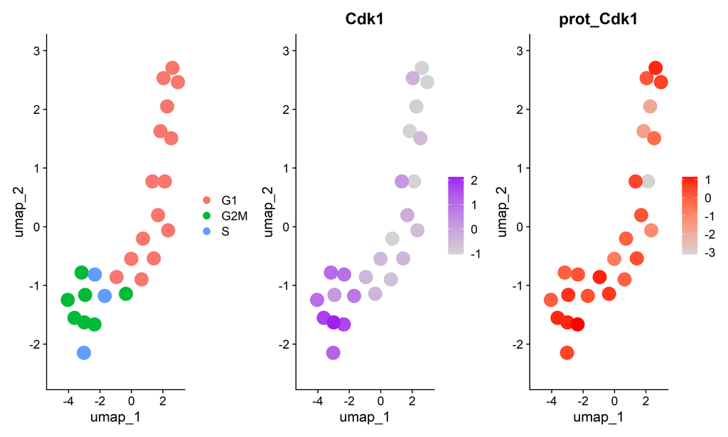